# Moose migration: Part II

Elie Gurarie

February 15, 2017

```r
rm(list=ls())
setwd("c:/users/elie/box sync/above/metamigration")
#require("rmarkdown")
#require("knitr")
```

Basic data manipulation / visualization packages:

```r
pcks <- c("plyr", "ggplot2", "ggmap", "ggthemes", "magrittr", "lubridate", "scales")
a <- lapply(pcks, require, character.only = TRUE, quietly = TRUE)
```

### Plotting (with elevation)

Some loaded moose data

```r
load(file = "./data/moose_daily.robj")
head(moose.daily)
```

```
##       id day            day.date        x       y       lon      lat
## 1 20A019 292 2011-10-20 12:00:00 486821.5 7077002 -147.2677 63.82016
## 2 20A019 293 2011-10-21 12:00:00 484069.6 7076186 -147.3235 63.81272
## 3 20A019 294 2011-10-22 12:00:00 481531.5 7074471 -147.3749 63.79720
## 4 20A019 295 2011-10-23 12:00:00 481989.1 7074286 -147.3656 63.79557
## 5 20A019 296 2011-10-24 12:00:00 482329.2 7073795 -147.3586 63.79118
## 6 20A019 297 2011-10-25 12:00:00 482286.3 7076284 -147.3598 63.81352
##                  time elevation
## 1 2011-10-20 21:51:22      1346
## 2 2011-10-21 11:40:53      1373
## 3 2011-10-22 10:24:46      1123
## 4 2011-10-23 11:20:43      1150
## 5 2011-10-24 11:10:50      1288
## 6 2011-10-25 11:01:18      1144
```

Note - to get the elevations I used the new `elevatr` package - doing something like this to the raw moose data:

```r
require(elevatr)
proj <- "+proj=longlat +ellps=WGS84 +datum=WGS84 +no_defs"
moose.daily <- mutate(moose.daily, elevation = get_elev_point(data.frame(x = lon, y = lat), prj = proj, src = "mapzen", api_key = "mapzen-91tYY4s")@data[,1])
```

This took some time (to access and download the elevation models.

```r
scan.track.z <- function(time, x, y, z, title = "",...)
{
  par(mar = c(0,3,0,0), oma = c(4,4,2,2))
 layout(rbind(c(1,2), c(1,3), c(1,4)))

  MakeLetter <- function(a, where="topleft", cex=2)
     legend(where, pt.cex=0, bty="n", title=a, cex=cex, legend=NA)

  plot(x,y,asp=1, type="o", pch=19, col=rgb(z/max(z),(1-z/(max(z))),0,.5), cex=0.5, ...); MakeLetter(title)
  plot(time,x, type="o", pch=19, col=rgb(0,0,0,.5), xaxt="n", xlab="", cex=0.5, ...); MakeLetter("X")
  plot(time,y, type="o", pch=19, col=rgb(0,0,0,.5), xaxt="n", xlab="", cex=0.5, ...); MakeLetter("Y")
  plot(time,z, type="o", pch=19, col=rgb(0,0,0,.5), cex=0.5, ...); MakeLetter("Z")
}
```

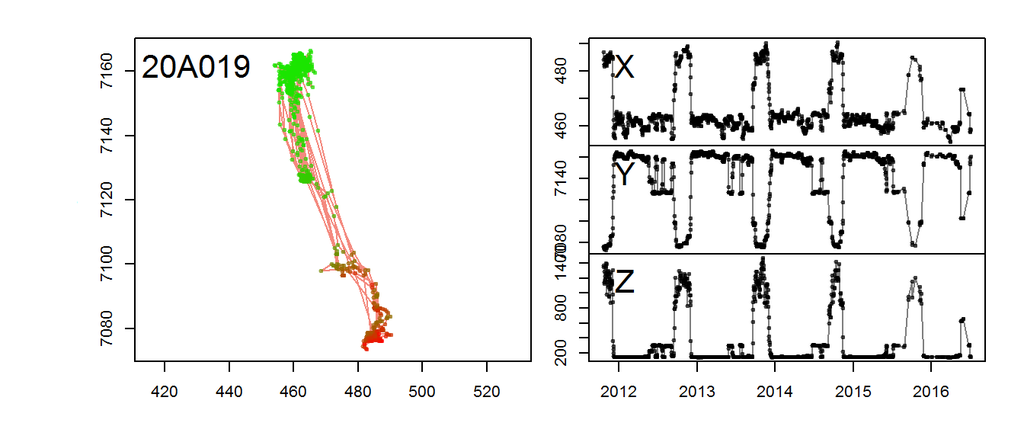

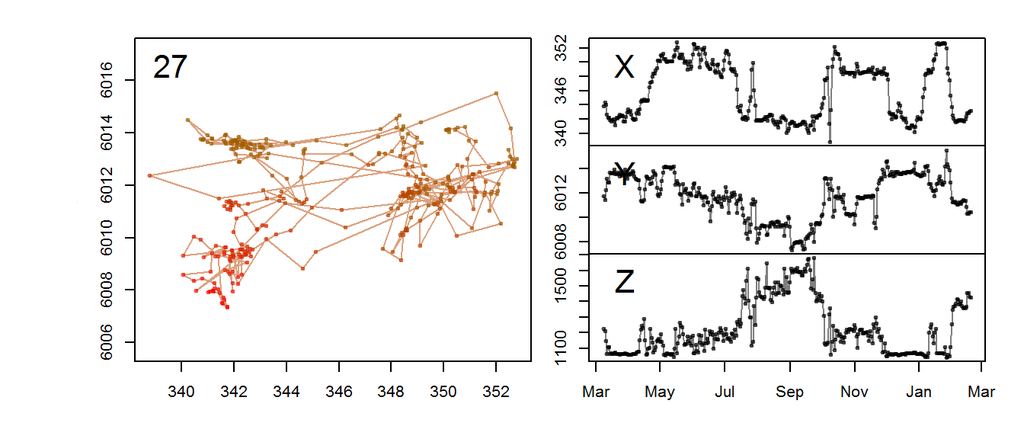

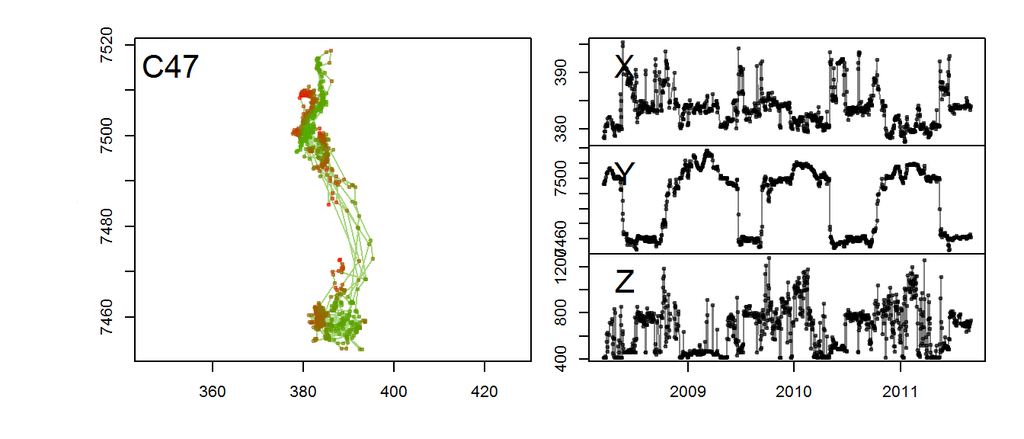

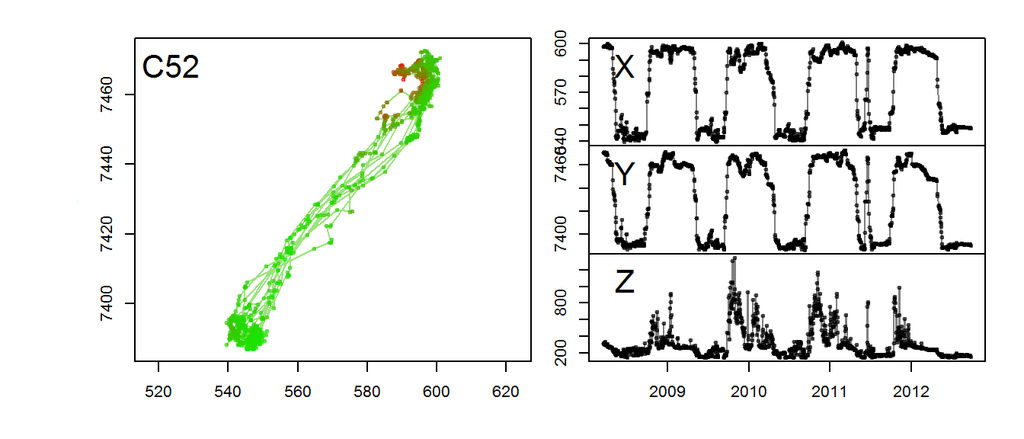

```r
par(las= 0)
for(me in levels(moose.daily$id))
with(subset(moose.daily, id == me), scan.track.z(time, x/1e3, y/1e3, elevation, me))
```

### Playing with MODIS

An important warning … the CRAN MODISTools does NOT work because of outdated / unsupported dependencies (see this thread: https://groups.google.com/forum/#!topic/predicts_project/FctDowcYgx0). You have to install if from GIT-hub:

```r
library(devtools)
install_git("http://github.com/seantuck12/MODISTools")
```

It might ask you to install a bunch of dependent packages (like `XML` - it did for me).

Load the package.

```r
require(MODISTools)
```

I don’t know too much about MODIS products, e.g. what product and band is best. But for now we’ll just get the NDVI value for “MOD13Q1” at just two locations - one in the summer range and one at the winter range.

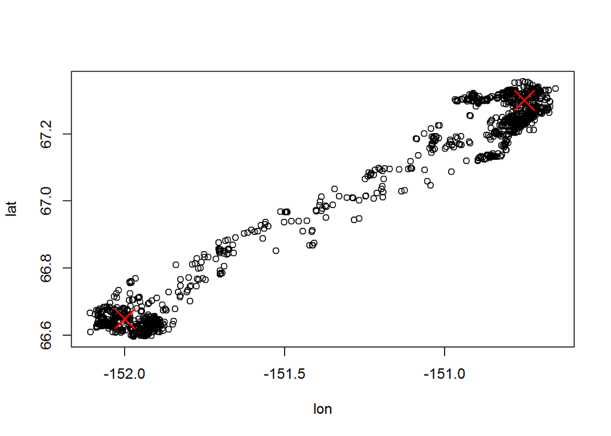

```r
summer <- c(-152, 66.65)
winter <- c(-150.75, 67.3)
points <- rbind(summer, winter)

with(subset(moose.daily, id == "C52"), plot(lon, lat))
points(points, col=2, pch = 4, cex=3, lwd=2)
```

The available bands are:

```r
product <- "MOD13Q1"
GetBands(product)
```

```
##  [1] "250m_16_days_blue_reflectance"
##  [2] "250m_16_days_MIR_reflectance"
##  [3] "250m_16_days_NIR_reflectance"
##  [4] "250m_16_days_pixel_reliability"
##  [5] "250m_16_days_red_reflectance"
##  [6] "250m_16_days_relative_azimuth_angle"
##  [7] "250m_16_days_sun_zenith_angle"
##  [8] "250m_16_days_view_zenith_angle"
##  [9] "250m_16_days_VI_Quality"
## [10] "250m_16_days_NDVI"
## [11] "250m_16_days_EVI"
## [12] "250m_16_days_composite_day_of_the_year"
```

Let’s go with NDVI

```r
band <- c("250m_16_days_NDVI")
pixel <- c(0,0)
```

You have to specify the x/y/time range of the desired data:

```r
period <- data.frame(lat=points[,2], long=points[,1], start.date=2008, end.date=2012, id=1)
```

The key function (and this takes a while) is `MODISSubsets`. This will download a file and save it in the specified `SaveDir`. This takes a while … multiple minutes on my computer.

```r
MODISSubsets(LoadDat = period, FileSep = "", Products = product, Bands = band, Size = pixel, SaveDir = "./data", StartDate = TRUE)
```

Files downloaded will be written to ./data. Found 2 unique time-series to download. Getting subset for location 1 of 2… Getting subset for location 2 of 2… Full subset download complete. Writing the subset download file… Done! Check the subset download file for correct subset information and download messages.

This function downloaded two files: `Lat66.65000Lon-152.00000Start2008-01-01End2012-12-31___MOD13Q1.asc` and `Lat67.30000Lon-150.75000Start2008-01-01End2012-12-31___MOD13Q1.asc`.

These are difficult files to parse, but there are some functions that simplify their analysis. `MODISTimeSeries` extracts the time series from all the available `.asc` files in the directory as a matrix:

```r
mooseNDVI.ts <- MODISTimeSeries(Dir = "./data", Band = band, Simplify = TRUE)
head(mooseNDVI.ts)
```

```
##          Lat66.65Lon-152Samp1Line1_pixel1
## A2008001                            -3000
## A2008017                            -1988
## A2008033                              976
## A2008049                              831
## A2008065                              466
## A2008081                              792
##          Lat67.3Lon-150.75Samp1Line1_pixel1
## A2008001                              -3000
## A2008017                               -570
## A2008033                                -45
## A2008049                                321
## A2008065                                276
## A2008081                                376
```

```r
colnames(mooseNDVI.ts) <- c("ndvi.summer", "ndvi.winter")
```

The row names of this matrix contain the date of the measurement, as the YEAR-DAYOFYEAR. This takes some manipulation to turn into a POSIX:

```r
require(lubridate)
mooseNDVI.ts <- data.frame(mooseNDVI.ts, date = ymd(paste(substring(row.names(mooseNDVI.ts), 2,5), 1, 1)) +
  ddays(as.numeric(substring(row.names(mooseNDVI.ts), 6))))
```

Ok, now we can at least plot these NDVI bands underneath the migration of the moose:

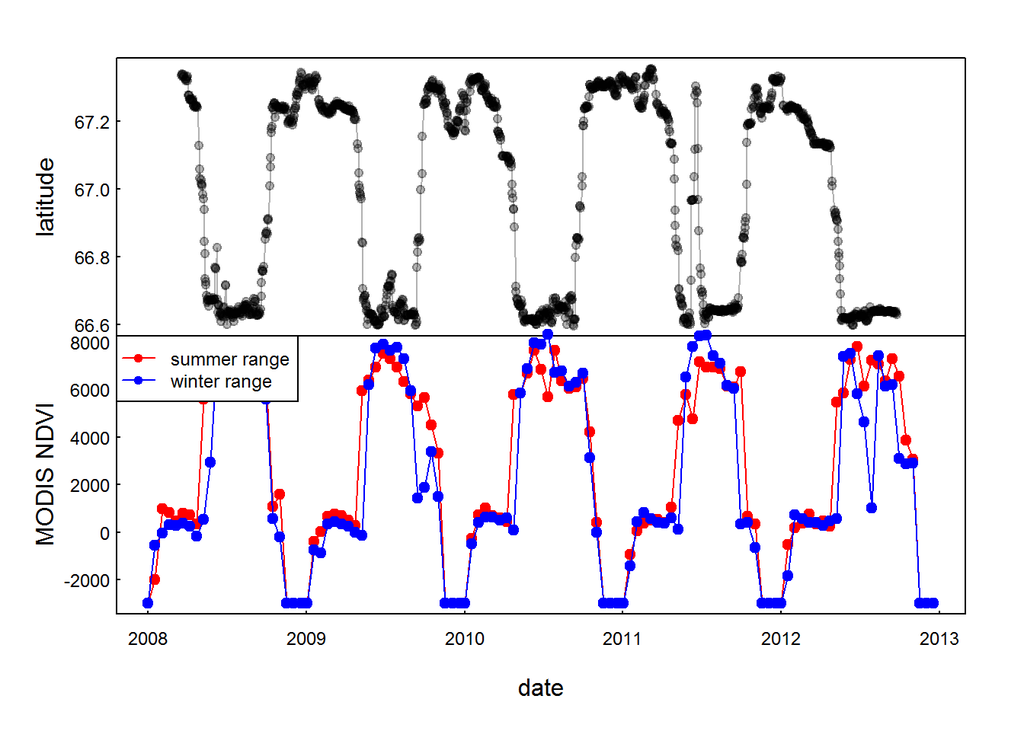

```r
with(subset(moose.daily, id == "C52"),
     plot(time, lat, type="o", xlim = range(mooseNDVI.ts$date), xlab = "", xaxt="n", ylab = "latitude", pch = 19, col = rgb(0,0,0,.3), cex = 0.8))

with(mooseNDVI.ts,{
    plot(date, ndvi.summer, type="o", pch = 19, col = 2, ylab = "MODIS NDVI")
    lines(date, ndvi.winter, type="o", pch = 19, col = 4)
})
legend("topleft", col = c(2,4), legend = c("summer range", "winter range"), pch = 19, lty = 1, cex=0.75)
```

There’s not a lot of difference in the winter and summer ranges. Interesting that (superficially) it looks like the moose are initiating their winter migration *before* the plummeting in the NDVI actually happens.